# Regression analysis

Xiaotian Ding

2019/2/14

## HW4

6.5

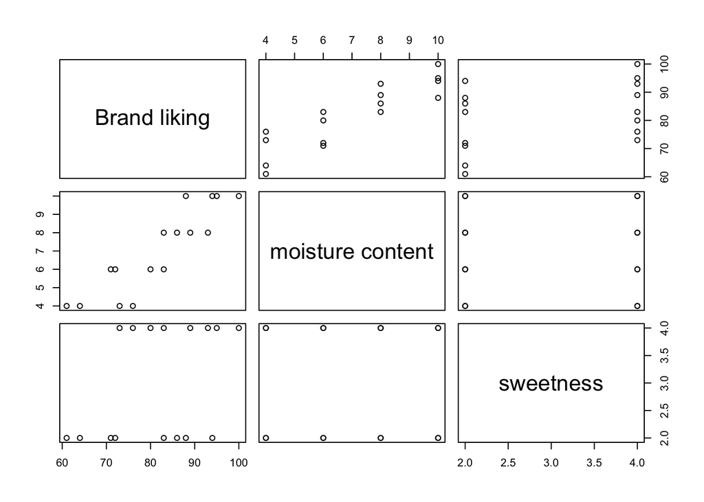

```r
Data<- read.table("CH06PR05.txt")
colnames(Data)<- c("Brand liking","moisture content","sweetness")
y<- Data$`Brand liking`
x1<- Data$`moisture content`
x2<- Data$sweetness
fitx1x2<- lm(y~x1+x2)
n<- dim(Data)[1]
b1<-fitx1x2$coefficients[2]
b2<-fitx1x2$coefficients[3]
yhat<- b1*x1+b2*x2
p<- 3
pairs(Data[,c(1,2,3)])
```

```r
cor(Data[,c(1,2,3)])
```

```
##                  Brand liking moisture content sweetness
## Brand liking        1.0000000        0.8923929 0.3945807
## moisture content    0.8923929        1.0000000 0.0000000
## sweetness           0.3945807        0.0000000 1.0000000
```

Both moisture content and sweetness can impact brand liking. Moisture content has more impact factor in brand liking.

E{Y|x1,x2}=37.650+4.425x1+4.3750x2

When the degree of moisture content increases one and sweetness is held constant, the brand liking degree increases 4.425.

```r
Residual<- fitx1x2$residuals
Residual
```

```
##     1     2     3     4     5     6     7     8     9    10    11    12
## -0.10  0.15 -3.10  3.15 -0.95 -1.70 -1.95  1.30  1.20 -1.55  4.20  2.45
##    13    14    15    16
## -2.65 -4.40  3.35  0.60
```

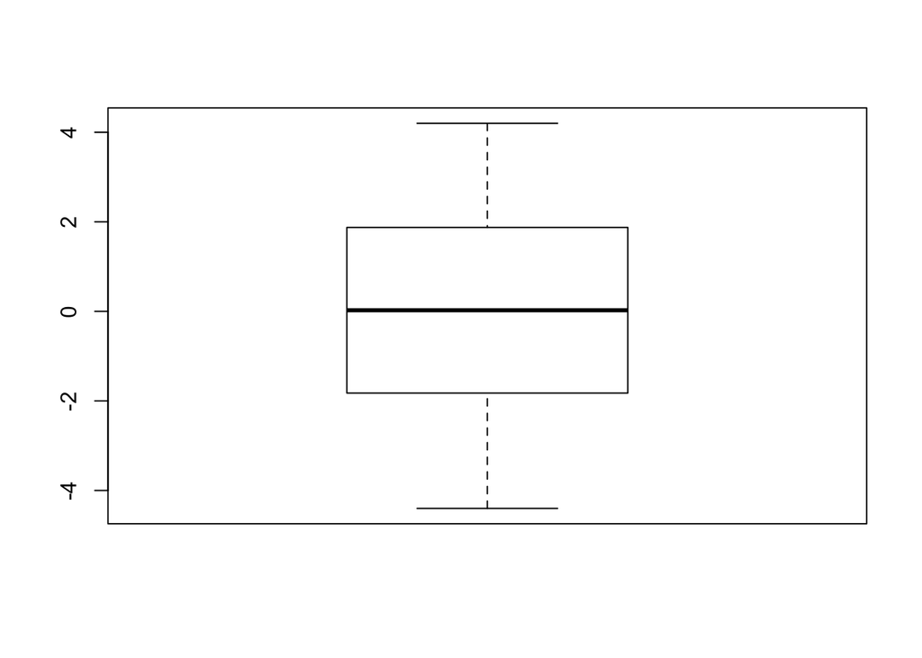

```r
boxplot(Residual)
```

The mean of residual near to zero without obviously offset and no outliers.

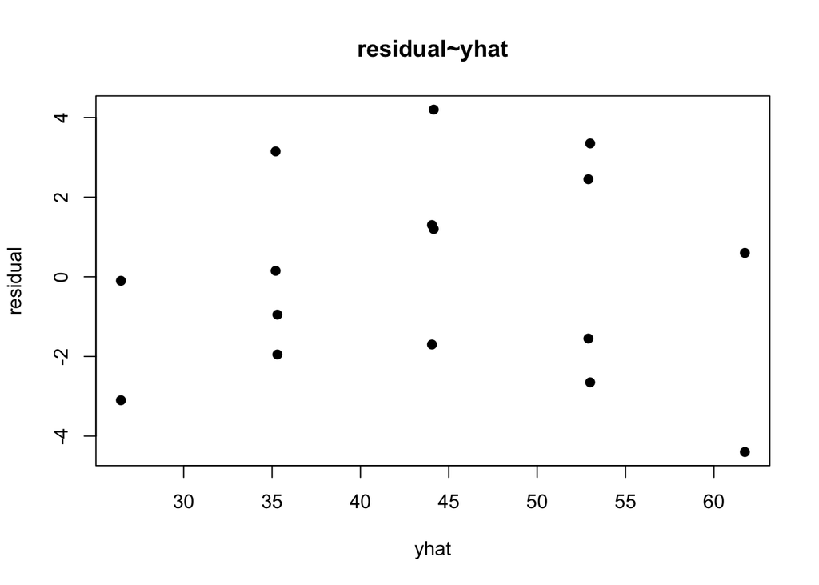

```r
# Residuals scatt around zero. The regression model follow the linear model.
plot(yhat,Residual,xlab = "yhat",ylab = "residual", main = "residual~yhat", pch=19)
```

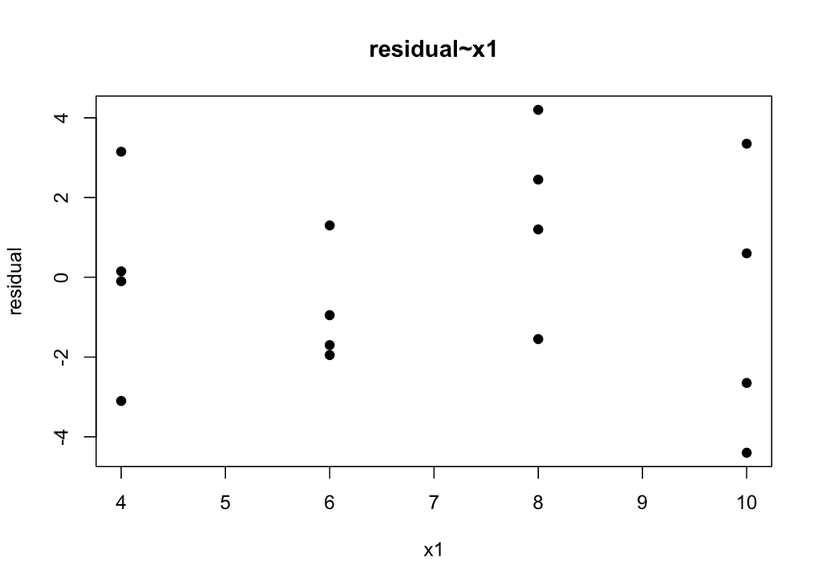

```r
# The x1 is related to y and the regression model has constant variance.
plot(x1,Residual,xlab = "x1",ylab = "residual", main = "residual~x1", pch=19)
```

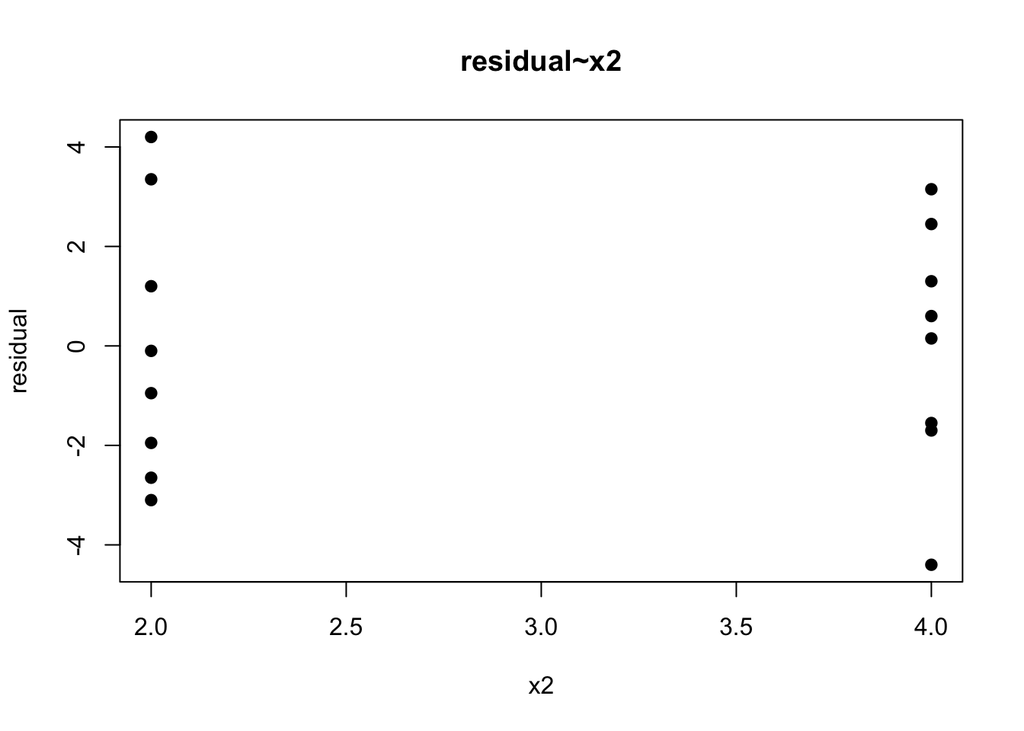

```r
# The x2 is related to y and the regression model has constant variance.
plot(x2,Residual,xlab = "x2",ylab = "residual", main = "residual~x2", pch=19)
```

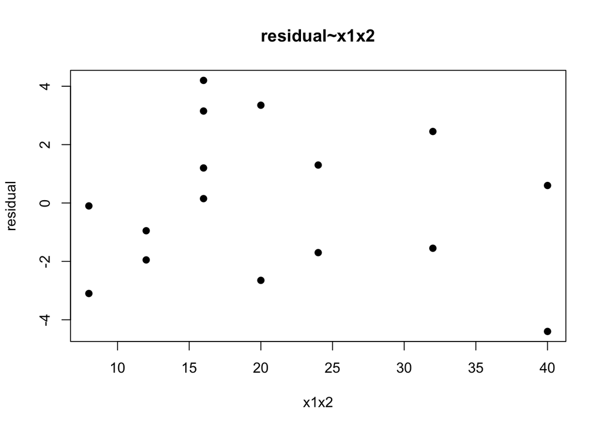

```r
# The x1x2 is related to y and the regression model has constant variance.
plot(x1*x2,Residual, xlab = "x1x2",ylab = "residual",main = "residual~x1x2", pch=19)
```

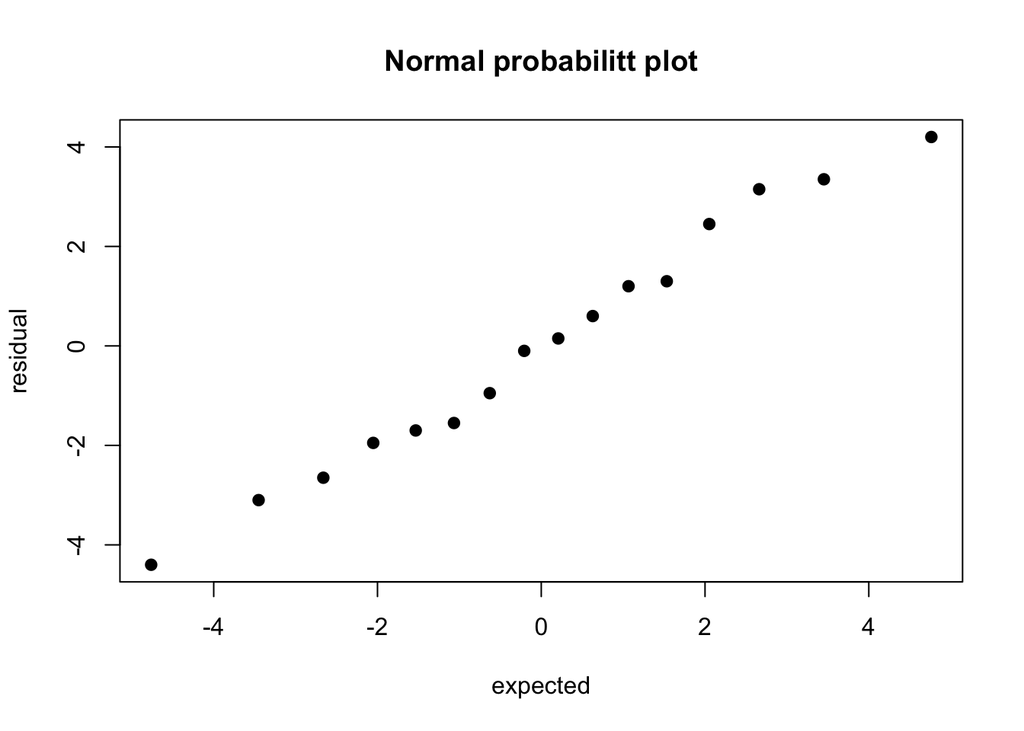

```r
res.sorted<- sort(fitx1x2$residuals)
MSE<- anova(fitx1x2)[3,3]
seq<- c(1:n)
percentile<- (seq-0.375)/(n+0.25)
res.expected<- sqrt(MSE)*qnorm(percentile)
plot(res.expected,res.sorted,xlab = "expected", ylab = "residual", main = "Normal probabilitt plot", pch=19)
```

```r
# The line is almost close to y=x, so the function follow normal distribution.
```

6.6

```r
#F-test to get whether regression relationship
anova(fitx1x2)
```

```
## Analysis of Variance Table
##
## Response: y
##           Df  Sum Sq Mean Sq F value    Pr(>F)
## x1         1 1566.45 1566.45 215.947 1.778e-09 ***
## x2         1  306.25  306.25  42.219 2.011e-05 ***
## Residuals 13   94.30    7.25
## ---
## Signif. codes:  0 '***' 0.001 '**' 0.01 '*' 0.05 '.' 0.1 ' ' 1
```

```r
MSR<- sum(anova(fitx1x2)[1:2,2])/(p-1)
MSE<- anova(fitx1x2)[3,3]
F<-MSR/MSE
qf(1-0.01,p-1,n-p)
```

```
## [1] 6.700965
```

H0: beta1= beta2=0

Ha: At least one beta ≠0

RR: abs(F)≥F(1-0.01,dfR-dfF,dfF)

From summary(fitx1x2): F=129.08 > F(1-0.01,2,13)=6.7

Thus, we reject H0 and conclude Ha.

There is a regression function and beta1 and beta2 at least one of them not equal to zero

```r
1-pf(F,p-1,n-p)
```

```
## [1] 2.658261e-09
```

In the test, p-value= 2.658261e-09

```r
#Bofferroni
g<-2
a<-0.01
t<-qt(1-a/(2*g),n-p)
summary(fitx1x2)
```

```
##
## Call:
## lm(formula = y ~ x1 + x2)
##
## Residuals:
##    Min     1Q Median     3Q    Max
## -4.400 -1.762  0.025  1.587  4.200
##
## Coefficients:
##             Estimate Std. Error t value Pr(>|t|)
## (Intercept)  37.6500     2.9961  12.566 1.20e-08 ***
## x1            4.4250     0.3011  14.695 1.78e-09 ***
## x2            4.3750     0.6733   6.498 2.01e-05 ***
## ---
## Signif. codes:  0 '***' 0.001 '**' 0.01 '*' 0.05 '.' 0.1 ' ' 1
##
## Residual standard error: 2.693 on 13 degrees of freedom
## Multiple R-squared:  0.9521, Adjusted R-squared:  0.9447
## F-statistic: 129.1 on 2 and 13 DF,  p-value: 2.658e-09
```

```r
b1<-fitx1x2$coefficients[2]
b2<-fitx1x2$coefficients[3]
sb1<- summary(fitx1x2)$coefficients[2,2]
sb2<-summary(fitx1x2)$coefficients[3,2]
b1+t*sb1
```

```
##       x1
## 5.440517
```

```r
b1-t*sb1
```

```
##       x1
## 3.409483
```

```r
b2+t*sb2
```

```
##       x2
## 6.645764
```

```r
b2-t*sb2
```

```
##       x2
## 2.104236
```

beta1 ∈ (3.409483,5.440517)

Considering x1 and x2 together,when x1 increase one unit, the change in Y on average is between 3.41 to 5.44.

beta2 ∈ (2.104236,6.645764)

Considering x1 and x2 together,when x2 increase one unit, the change in Y on average is between 2.10 to 6.65.

6.7

```r
summary(fitx1x2)
```

```
##
## Call:
## lm(formula = y ~ x1 + x2)
##
## Residuals:
##    Min     1Q Median     3Q    Max
## -4.400 -1.762  0.025  1.587  4.200
##
## Coefficients:
##             Estimate Std. Error t value Pr(>|t|)
## (Intercept)  37.6500     2.9961  12.566 1.20e-08 ***
## x1            4.4250     0.3011  14.695 1.78e-09 ***
## x2            4.3750     0.6733   6.498 2.01e-05 ***
## ---
## Signif. codes:  0 '***' 0.001 '**' 0.01 '*' 0.05 '.' 0.1 ' ' 1
##
## Residual standard error: 2.693 on 13 degrees of freedom
## Multiple R-squared:  0.9521, Adjusted R-squared:  0.9447
## F-statistic: 129.1 on 2 and 13 DF,  p-value: 2.658e-09
```

From summary, R^2= 0.9521

95.21% of y is explained by x1 and x2.

```r
yhat<- b1*x1+b2*x2
fityyhat<-lm(yhat~y)
summary(fityyhat)
```

```
##
## Call:
## lm(formula = yhat ~ y)
##
## Residuals:
##     Min      1Q  Median      3Q     Max
## -3.9963 -1.4077 -0.1473  1.6865  5.0352
##
## Coefficients:
##             Estimate Std. Error t value Pr(>|t|)
## (Intercept) -33.7308     4.7105  -7.161 4.85e-06 ***
## y             0.9521     0.0571  16.674 1.25e-10 ***
## ---
## Signif. codes:  0 '***' 0.001 '**' 0.01 '*' 0.05 '.' 0.1 ' ' 1
##
## Residual standard error: 2.532 on 14 degrees of freedom
## Multiple R-squared:  0.9521, Adjusted R-squared:  0.9486
## F-statistic:   278 on 1 and 14 DF,  p-value: 1.246e-10
```

The R^2 between Yi and Yhat is 0.9521.

It is equal to cofficient of multiple determination in part(a).

6.8 a.

```r
h1<- data.frame(x1=5,x2=4)
predict(fitx1x2,h1,interval = "confidence",level = 0.99)
```

```
##      fit      lwr      upr
## 1 77.275 73.88111 80.66889
```

The C.I. is (73.88111,80.66889)

When moisture content degree is 5 and sweetness degress is 4 in 99% cofidence, the probability of the mean of brand liking is 73.9% to 80.67%.

```r
predict(fitx1x2,h1,interval = "prediction",level = 0.99)
```

```
##      fit      lwr      upr
## 1 77.275 68.48077 86.06923
```

The C.I. is (68.48077,86.06923)

When moisture content degree is 5 and sweetness degress is 4 in 99% cofidence, the probability in this brand liking is 68.48% to 86.07%.

7.3 a.

```r
anova(fitx1x2)
```

```
## Analysis of Variance Table
##
## Response: y
##           Df  Sum Sq Mean Sq F value    Pr(>F)
## x1         1 1566.45 1566.45 215.947 1.778e-09 ***
## x2         1  306.25  306.25  42.219 2.011e-05 ***
## Residuals 13   94.30    7.25
## ---
## Signif. codes:  0 '***' 0.001 '**' 0.01 '*' 0.05 '.' 0.1 ' ' 1
```

SSR(x1)=1566.45

SSR(x2|x1)=306.25

```r
#F* test
dropx2<- lm(y~x1)
Fulla<- fitx1x2
anova(dropx2,Fulla)
```

```
## Analysis of Variance Table
##
## Model 1: y ~ x1
## Model 2: y ~ x1 + x2
##   Res.Df    RSS Df Sum of Sq      F    Pr(>F)
## 1     14 400.55
## 2     13  94.30  1    306.25 42.219 2.011e-05 ***
## ---
## Signif. codes:  0 '***' 0.001 '**' 0.01 '*' 0.05 '.' 0.1 ' ' 1
```

```r
a1=0.01
g1=1
F1=anova(dropx2,Fulla)[2,5]
qf(1-a1,p-1-g1,n-p)
```

```
## [1] 9.073806
```

```r
1-pf(F1,p-1-g1,n-p)
```

```
## [1] 2.011047e-05
```

H0: reduced model: E(Y)= beta0+ beta1x1

Ha: full model: E(Y)=beta0 + beta1x1+ beta2x2

RR: F1>F(1-a,p-1-g1,n-p)

F1=42.219>F(1-a,p-1-g1,n-p)=9.07

Thus, we reject H0 conclude Ha.

7.12

```r
anova(fitx1x2)
```

```
## Analysis of Variance Table
##
## Response: y
##           Df  Sum Sq Mean Sq F value    Pr(>F)
## x1         1 1566.45 1566.45 215.947 1.778e-09 ***
## x2         1  306.25  306.25  42.219 2.011e-05 ***
## Residuals 13   94.30    7.25
## ---
## Signif. codes:  0 '***' 0.001 '**' 0.01 '*' 0.05 '.' 0.1 ' ' 1
```

```r
anova(lm(y~x2))
```

```
## Analysis of Variance Table
##
## Response: y
##           Df  Sum Sq Mean Sq F value Pr(>F)
## x2         1  306.25  306.25  2.5817 0.1304
## Residuals 14 1660.75  118.62
```

```r
"SSEx2"=anova(lm(y~x2))[2,2]
"SSEx1"=anova(lm(y~x1))[2,2]
SSRx1= anova(fitx1x2)[1,2]
"SSRx2|x1"= anova(fitx1x2)[2,2]
SSTO=sum(anova(fitx1x2)[,2])
"Ry1^2"=SSRx1/SSTO
"Ry2^2"=`SSRx2|x1`/SSTO
"R12^2"=0
"Ry1|2^2"=SSRx1/SSEx2
"Ry2|1^2"=`SSRx2|x1`/SSEx1
```

Ry1^2=0.796365

When only concerning x1, 79.64% of y are explained.

Ry2^2=0.155694

When only concerning x2, 15.57% of y are explained.

R12^2=0

When concerning both x1 and x2, 0% can explain each other.

Ry1|2^2=0.943218

When x1 is added to regression model containing x2, the SSEx2 will be reduced by 94.32%.

Ry2|1^2=0.764574

R^2=0.9521

When concerning x2 and x1, 95.21% of y are explained.

7.24 a.

```r
fitx1<- lm(y~x1)
summary(fitx1)
```

```
##
## Call:
## lm(formula = y ~ x1)
##
## Residuals:
##    Min     1Q Median     3Q    Max
## -7.475 -4.688 -0.100  4.638  7.525
##
## Coefficients:
##             Estimate Std. Error t value Pr(>|t|)
## (Intercept)   50.775      4.395  11.554 1.52e-08 ***
## x1             4.425      0.598   7.399 3.36e-06 ***
## ---
## Signif. codes:  0 '***' 0.001 '**' 0.01 '*' 0.05 '.' 0.1 ' ' 1
##
## Residual standard error: 5.349 on 14 degrees of freedom
## Multiple R-squared:  0.7964, Adjusted R-squared:  0.7818
## F-statistic: 54.75 on 1 and 14 DF,  p-value: 3.356e-06
```

E{Y|x1}=50.775+4.425x1

E{Y|x1,x2}=37.650+4.425x1+4.3750x2

the beta for x1 in two regression is the same, which means that x1, x2 are uncorelated.

```r
anova(fitx1)
```

```
## Analysis of Variance Table
##
## Response: y
##           Df  Sum Sq Mean Sq F value    Pr(>F)
## x1         1 1566.45 1566.45  54.751 3.356e-06 ***
## Residuals 14  400.55   28.61
## ---
## Signif. codes:  0 '***' 0.001 '**' 0.01 '*' 0.05 '.' 0.1 ' ' 1
```

SSR(x1)=1566.45

SSR(x1|x2)= 1566.45

They are the same.

x1 and x2 have impact on y, but they have no impact on each other.